# Almond Yield Assignment

2024 April 12

# Instructions

In your same groups -

- Develop a profit model for your almond yield (you can make this up - think about what the parameters would be)

  ```
  * you might assume a baseline profit and then adjust according to the anomaly
  ```

  - there are many ways to combine the almond yield and profit functions; you can have the profit function “call”/use the almond yield function; or create a wrapper function that calls them in sequence (first the almond yield and then the profit function)
- Do a simple informal sensitivity analysis of almond yield profit using at least 2 parameters
- Create 2 graphs of the results - you can decide what is the most meaningful graph
- Write a short paragraph (in the Rmarkdown document) to summarize you interpretation of your model results (e.g what do ‘take away’ from your model and sensitivity analysis)

# Code

### Set up

```r
# chunk settings
knitr::opts_chunk$set(echo = TRUE#, message = FALSE, warning = FALSE
                      )
# libraries
library(tidyverse)
library(purrr)
library(here)
library(patchwork)
library(RColorBrewer)

# load data
clim <- read.delim(here('assignments','clim.txt'),
                   header = TRUE,
                   sep = " ")
```

### Wrangle Monthly Data

```r
# Calculate monthly average minimum and maximum temperatures
monthly_clim <- clim %>%
  # this order was selected so we can easily access the previous month's total precip
  group_by(year, month) %>%
  summarize(min_tmin_c = min(tmin_c),
            total_precip = sum(precip)) %>%
  # to assess almond yield profit overtime
  filter(month == c(1, 2))
head(monthly_clim)
```

```
## # A tibble: 6 × 4
## # Groups:   year [3]
##    year month min_tmin_c total_precip
##   <int> <int>      <dbl>        <dbl>
## 1  1989     1       3.90         2.80
## 2  1989     2       2.71        96.4
## 3  1990     1       3.90        55.8
## 4  1990     2       3.15        47.9
## 5  1991     1       5.04       135.
## 6  1991     2       5.91         0
```

### Testing Updated Function

```r
source(here::here("R/almond_yield.R"))
almond_yield(monthly_clim)
```

```
##    Year Month         Yield
## 1  1989     2  4.321564e-02
## 2  1990     2  9.674775e+00
## 3  1991     2  6.931641e+01
## 4  1992     2  1.582346e+01
## 5  1993     2  2.049452e+01
## 6  1994     2  2.859874e+00
## 7  1995     2  1.920308e+03
## 8  1996     2  4.185522e+00
## 9  1997     2  3.299805e+02
## 10 1998     2  2.819993e+01
## 11 1999     2  1.086940e-01
## 12 2000     2  9.812790e+00
## 13 2001     2  1.597531e+02
## 14 2002     2  4.636613e-01
## 15 2003     2 -2.682371e-02
## 16 2004     2 -8.045354e-03
## 17 2005     2  6.567218e+02
## 18 2006     2  1.895726e+01
## 19 2007     2  2.050888e+01
## 20 2008     2  5.765393e+02
## 21 2009     2  9.821028e-01
## 22 2010     2  1.539978e+02
```

# Net Present Value Function (NPV)

```r
#' compute_NPV
#'
#' compute net present value
#' @param value/cost ($)
#' @param time in the future that cost/value occurs (years)
#' @param discount rate
#' @return value in $


compute_NPV = function(cost, time, discount=0.12) {
    result = cost / (1 + discount)**time
    return(result)
}
```

# Profit Yield Function

# Wrapper function that calls the yield function, and then the profit function

```r
#' computes profit from almond yield
#' @param  price ($/kj)
#' @param  yield (ton/acre)
#' @param  year (when was energy obtained)
#' @param discount rate (default 0.12)
#' @return data frame with estimate of profit
compute_profit_fromyield = function(df, year, Yield, price, discount=0.12) {

  yield_df <- almond_yield(df)

  profit_df <- yield_df %>%
    select(-Yield) %>%
    mutate(net = Yield*price,
           netpre = compute_NPV(cost=net,
                                time=Year-Year[1], # remember to normalize the year to start year e.g the first year
                                discount=0.12))
  profit_df <- profit_df %>%
     filter(Year == year)

  return(profit_df)
}

compute_profit_fromyield(monthly_clim, year = 1995, Yield = 0.5, price = 1000)
```

```
##   Year Month net   netpre
## 1 1995     2 500 253.3156
```

# Sensitivty Analysis on 2 Parameters

**pulling from `InformalSensitivity2.Rmd``**

```r
#. FROM CLASS
# generate samples for both parameters
nsamples = 300
deviation = 0.15
base_yield = 0.9 # based on the paper
Yield = runif(min = base_yield - deviation*base_yield,
                max = base_yield + deviation*base_yield,
                n=nsamples)

price = rnorm(mean=4000, sd = 1000, n=nsamples)

parms = cbind.data.frame(Yield, price)

# use pmap
# takes function name and then names of all parameters that don't change
results = parms %>%
  pmap(compute_profit_fromyield, year = 1995,
       df = monthly_clim, discount = 0.12)

results[[1]]
```

```
##   Year Month      net  netpre
## 1 1995     2 3238.608 1640.78
```

```r
length(results)
```

```
## [1] 300
```

```r
# now we can extract results from the list as above
profit_y_95 = map_df(results,`[`, c("netpre"))
# and we can add the parameter values for each run
profit_y_95 = cbind.data.frame(profit_y_95, parms)

# plot - pick on of the 2 parameter as a color

p1 = ggplot(profit_y_95, aes(x = Yield,
                          y = netpre,
                          col=price)) +
  geom_point(cex=2) +
  theme_minimal() +
  scale_color_fermenter(palette = "RdPu", direction = 1) +
  labs(y="Net Profit",
       x="Almond yield (ton/acre)")

p2 <- ggplot(profit_y_95, aes(x = price,
                             y = netpre, col=Yield)) +
  geom_jitter(cex=2) +
  theme_minimal() +
  scale_color_fermenter(palette = "RdPu", direction = 1) +
  labs(y="Net Profit",
       x="Price per acre")
```

### Visuals

These informal sensitivity analysises were performed simultaneously for a the year 1995. Our visual provides sufficient evidence to conclude that the profit model is more sensitive to price per acre compared to the almond crop yield. It is possible that the strong affect of price on profits may obscure the affect of yield on the profit model.

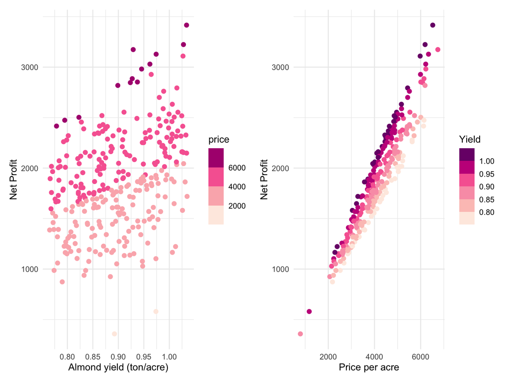

```r
p1 + p2
```